# More about vectors

# Some handy functions

There are some general functions that are handy when doing statistics.

# Sums

You can use `sum` to add the elements of one or more numerical vectors:

```r
sum(1:10)
```

```
[1] 55
```

```r
sum(c(1.2, 2.3, 3.4))
```

```
[1] 6.9
```

```r
sum(1:2, 3:5) # Two vectors
```

```
[1] 15
```

If there are missing values then the sum is unknown, so the result is `NA`:

```r
sum(1:5, NA)
```

```
[1] NA
```

You can tell the sum function to ignore missing values by adding the argument `na.rm=TRUE`

```r
sum(1:5, NA, na.rm=TRUE)
```

```
[1] 15
```

# Differences

You can get the **lagged differences** of the elements in a numeric vector using diff. For each element, starting from the second, the difference between it and the previous element is calculated. Notice that the resulting vector has one fewer elements.

```r
x <- c(2, 4, 5, 4, 6, 8) # Six elements
diff(x) # Five elements
```

```
[1]  2  1 -1  2  2
```

# Cumulatives

You can get the cumulative sum of the values in a numerical vector using the `cumsum` function:

```r
cumsum(c(2, 3, 1, 4, 2, 3, 4, 5, 6, 0, 4))
```

```
 [1]  2  5  6 10 12 15 19 24 30 30 34
```

Similarly, you can get the cumulative product, cumulative maximum, and cumulative minimum:

```r
x <- c(2, 3, 1, 4, 2, 3, 4, 5, 6, 0, 4)
cumprod(x)
```

```
 [1]     2     6     6    24    48   144   576  2880 17280     0     0
```

```r
cummax(x)
```

```
 [1] 2 3 3 4 4 4 4 5 6 6 6
```

```r
cummin(x)
```

```
 [1] 2 2 1 1 1 1 1 1 1 0 0
```

# Factorials

If n is an integer with $n \geq 1$ then the factorial of n is defined to be $1 \times 2 \times ... \times n$. R has a function `factorial` that calculates factorials:

```r
factorial(10)
```

```
[1] 3628800
```

Let’s check this by calculating the factorial explicitly:

```r
# One way
1 * 2 * 3 * 4 * 5 * 6 * 7 * 8 * 9 * 10
```

```
[1] 3628800
```

```r
# Another way
cumprod(1:10)[10] # Get the last cumulative product
```

```
[1] 3628800
```

The `factorial` function is vectorised, which means that you can apply it to a vector of integers and get the factorial of each integer in the vector:

```r
factorial(1:5)
```

```
[1]   1   2   6  24 120
```

# Combinations

Suppose you choose a sample of n objects from a population of N objects, without replacement. This sample is called a **combination**. How many such combinations are there? Answer:

$$\begin{pmatrix}N \\n \\\end{pmatrix} =
\dfrac{N!}{n!(N-n)!}$$

R has a function choose that calculates this number:

```r
choose(10, 3)
```

```
[1] 120
```

Let’s check this, by calculating the number explicitly:

```r
factorial(10)/(factorial(3)*factorial(10 - 3))
```

```
[1] 120
```

If you’d like to actually generate the combinations of a given length from a vector then you can use `combn`:

```r
x <- c(1, 2, 3, 4, 5)
combn(x, 3)
```

```
     [,1] [,2] [,3] [,4] [,5] [,6] [,7] [,8] [,9] [,10]
[1,]    1    1    1    1    1    1    2    2    2     3
[2,]    2    2    2    3    3    4    3    3    4     4
[3,]    3    4    5    4    5    5    4    5    5     5
```

# Random samples

The sample function gives you a way to generate random samples of data.

```r
# A random shuffle of the first 30 positive integers
sample(30)
```

```
 [1] 29 16  5 20 27  3 18 10 19 22 24 28 11 17 26  6  1 12  9 14  2  8 15 30 23
[26] 13  7 21  4 25
```

```r
# A random sample of 10 taken from the first 30 positive integers, without replacement
sample(30, size=10)
```

```
 [1]  9 28 30  7 21  4 29 23  3 18
```

```r
# A random sample of 10 taken from the first 30 positive integers, with replacement
sample(30, size=10, replace=TRUE)
```

```
 [1] 21 13 19 19  4  2 20  2 16 16
```

# Summarising data

Suppose you have some numerical values in a vector. R has a variety of functions to help you summarise the values.

## Mean and median

You can use the functions `mean` and `median` to find the mean and median of the values:

```r
x <- sample(100, size=20, replace=TRUE)
x
```

```
 [1]  61  57  52  12  36  56  64  28  61  99  80  32  17  57  30 100  14  78  67
[20]  34
```

```r
mean(x)
```

```
[1] 51.75
```

```r
median(x)
```

```
[1] 56.5
```

If there are any `NA`s in the vector then the results will be `NA`:

```r
# With NAs
mean(c(1:10, NA))
```

```
[1] NA
```

```r
median(c(1:10, NA))
```

```
[1] NA
```

You can tell R to ignore the NAs by adding `na.rm=TRUE`:

```r
# Ignore the NAs
mean(c(1:10, NA), na.rm=TRUE)
```

```
[1] 5.5
```

```r
median(c(1:10, NA), na.rm=TRUE)
```

```
[1] 5.5
```

If you’d like to exclude outliers from the calculations then you can add a `trim` argument. If you add `trim=0.1` then R will sort the elements and ignore the first 10% and the last 10% of them. So, if the vector has 20 elements then it will ignore the first 2 and the last 2.

```r
x <- sample(100, size=20, replace=TRUE)
x
```

```
 [1]  92  61  19  75  95  55  27  51  76  59   4   6 100  12  58  89  82  48  63
[20]  48
```

```r
mean(x, trim=0.1)
```

```
[1] 57.1875
```

```r
median(x, trim=0.1)
```

```
[1] 58.5
```

In many cases the numerical vector in which you are interested is a column of a data frame:

```r
# df <- read.csv('/course/data/survey.csv')
# Without ignoring NAs
# mean(df$hair.cost)
# median(df$hair.cost)
#
# Ignoring NAs
# mean(df$hair.cost, na.rm=TRUE)
# median(df$hair.cost, na.rm=TRUE)
```

# Range, variance, and standard deviation

You can use `min` and `max` to find the minimum and maximum values of a numerical vector:

```r
x <- sample(100, size=20, replace=TRUE)
x
```

```
 [1] 93 22 54  6 60 68 39 91  4 43 73 74 29 18 86 10  5 53 87 42
```

```r
min(x)
```

```
[1] 4
```

```r
max(x)
```

```
[1] 93
```

```r
# Check by sorting the values and inspecting:
sort(x)
```

```
 [1]  4  5  6 10 18 22 29 39 42 43 53 54 60 68 73 74 86 87 91 93
```

The `range` function returns the minimum and maximum values as a vector of length 2 (not their difference - the actual values):

```r
x <- sample(100, size=20, replace=TRUE)
x
```

```
 [1] 93 13 86 52 46 87 84 98 49 59  4  4 82 11 33 28 89 17 84 83
```

```r
range(x)
```

```
[1]  4 98
```

```r
# Check by sorting the values and inspecting
sort(x)
```

```
 [1]  4  4 11 13 17 28 33 46 49 52 59 82 83 84 84 86 87 89 93 98
```

You can get the variance and standard deviation using the `var` and `sd` functions:

```r
x <- sample(100, size=20, replace=TRUE)
x
```

```
 [1] 44 53 24 62 61  6 60 16 31 17 98 35 53 40 91 63 24  8 35 97
```

```r
var(x)
```

```
[1] 771.2526
```

```r
# Calculate the variance directly - should get the same result
sum((x - mean(x))^2)/(length(x) - 1)
```

```
[1] 771.2526
```

```r
sd(x)
```

```
[1] 27.77144
```

```r
# The square of this should be the variance
sd(x)^2
```

```
[1] 771.2526
```

# Quantiles

The `quantile` function calculates quantiles:

```r
x <- sample(100, size=20, replace=TRUE)
sort(x)
```

```
 [1]  5 20 21 32 33 37 44 44 47 53 55 56 83 83 85 88 89 93 94 99
```

```r
quantile(x)
```

```
   0%   25%   50%   75%  100%
 5.00 36.00 54.00 85.75 99.00
```

By default, the function returns the 0%, 25%, 50%, 75% and 100% quantiles. You can specify different quantiles using the `probs` argument:

```r
x <- sample(100, size=20, replace=TRUE)
sort(x)
```

```
 [1]  1  2  2  9  9 13 13 21 36 65 76 78 80 82 82 86 88 89 89 92
```

```r
quantile(x, probs=c(0.2, 0.4, 0.6, 0.8))
```

```
 20%  40%  60%  80%
 9.0 30.0 78.8 86.4
```

```r
quantile(x, probs=seq(from=0, to=1, by=0.1))
```

```
  0%  10%  20%  30%  40%  50%  60%  70%  80%  90% 100%
 1.0  2.0  9.0 13.0 30.0 70.5 78.8 82.0 86.4 89.0 92.0
```

# Summaries

The `summary` function returns a six number summary, showing the min, max, mean and other three quartiles:

```r
x <- sample(100, size=20, replace=TRUE)
sort(x)
```

```
 [1]   3   9   9  12  33  38  41  45  62  63  65  68  69  70  77  77  80  92  93
[20] 100
```

```r
summary(x)
```

```
   Min. 1st Qu.  Median    Mean 3rd Qu.    Max.
   3.00   36.75   64.00   55.30   77.00  100.00
```

# Grouping

Using the techniques above you can summarise a column of a data frame, let’s say the petal length column of the iris data frame. Here’s how you might find the mean and standard deviation:

```r
mean(iris$Petal.Length)
```

```
[1] 3.758
```

```r
sd(iris$Petal.Length)
```

```
[1] 1.765298
```

But what if you want to calculate these values individually for each species?

You could filter the data frame three times, once for each species:

```r
filtered <- iris[iris$Species == 'setosa', ]
mean(filtered$Petal.Length)
```

```
[1] 1.462
```

```r
sd(filtered$Petal.Length)
```

```
[1] 0.173664
```

```r
filtered <- iris[iris$Species == 'versicolor', ]
mean(filtered$Petal.Length)
```

```
[1] 4.26
```

```r
sd(filtered$Petal.Length)
```

```
[1] 0.469911
```

```r
filtered <- iris[iris$Species == 'virginica', ]
mean(filtered$Petal.Length)
```

```
[1] 5.552
```

```r
sd(filtered$Petal.Length)
```

```
[1] 0.5518947
```

But that’s repetitive, and it requires you to know the species in advance.

A better way is to use the function `by`:

```r
by(iris$Petal.Length, iris$Species, FUN=mean)
```

```
iris$Species: setosa
[1] 1.462
------------------------------------------------------------
iris$Species: versicolor
[1] 4.26
------------------------------------------------------------
iris$Species: virginica
[1] 5.552
```

```r
by(iris$Petal.Length, iris$Species, FUN=sd)
```

```
iris$Species: setosa
[1] 0.173664
------------------------------------------------------------
iris$Species: versicolor
[1] 0.469911
------------------------------------------------------------
iris$Species: virginica
[1] 0.5518947
```

# Tabulating frequencies

You can generate a frequency table for a vector - a table that shows the frequency of each value in the vector - using the `table` function. It works for both numeric and non-numeric vectors:

```r
x <- c(1:5, 3:7, 5:9)
table(x)
```

```
x
1 2 3 4 5 6 7 8 9
1 1 2 2 3 2 2 1 1
```

```r
x <- c('PS', 'CR', 'PS', 'DI', 'DI', 'DI')
table(x)
```

```
x
CR DI PS
 1  3  2
```

```r
x <- c(TRUE, TRUE, TRUE, FALSE, FALSE)
table(x)
```

```
x
FALSE  TRUE
    2     3
```

By default, `NA`s are not tabulated. If you’d like to include `NA`s then you can add either `useNA='ifany'`, which gets R to include the number of NAs but only if it’s greater than zero, or `useNA='always'`, which gets R to include the number of NAs even if it’s zero.

```r
x <- c('PS', 'CR', NA, 'PS', 'DI', 'DI', 'DI', NA)
table(x)
```

```
x
CR DI PS
 1  3  2
```

```r
table(x, useNA='ifany')
```

```
x
  CR   DI   PS <NA>
   1    3    2    2
```

The vector you are tabulating could be a column of a data frame:

```r
# x <- read.csv('/course/data/survey.csv')
# table(x$gender, useNA='ifany')
```

You can also tabulate the frequency of *pairs* of values, by providing the function with two vectors. For each combination of values, the function calculates the frequency of that combination. Here’s an example using two columns from a data frame:

```r
# x <- read.csv('/course/data/survey.csv')
# table(x$gender, x$study.area, useNA='ifany')
```

# working with distributions

R can help you work with a wide variety of probability distributions.

For each distribution there are four key functions. For the binomial distribution they are: `dbinom`, `pbinom`, `qbinom`, and `rbinom`. For the normal distribution they are `dnorm`, `pnorm`, `qnorm`, and `rnorm`. And so on. In general, they are `d----`, `p----`, `q----`, and `r----`.

### p—-

This is the cumulative distribution function of the distribution. That is, for any value x it gives the probability p such that:

$$p = P(X \leq x)$$

(The cumulative distribution function and the quantile function are inverses of each other.)

### r—-

This gives a random selection of values from the distribution.

The next fours slides illustrate these functions for two common discrete distributions (binomial and geometric) and two common continuous distributions (uniform and normal).

# the binomial distribution

Consider the random process of tossing a fair coin 10 times. Let $X$ be the number of heads that are tossed in the process. Then $X$ is a discrete random variable, whose probability distribution is binomial, with parameters $n=10$ and $p=0.5$. That is:

$$X \sim \text{Bin}(10,0.5)$$

# The probability function (dbinom)

In R this function is called `dbinom(x, size=10, prob=0.5)`. You can plot the function using curve:

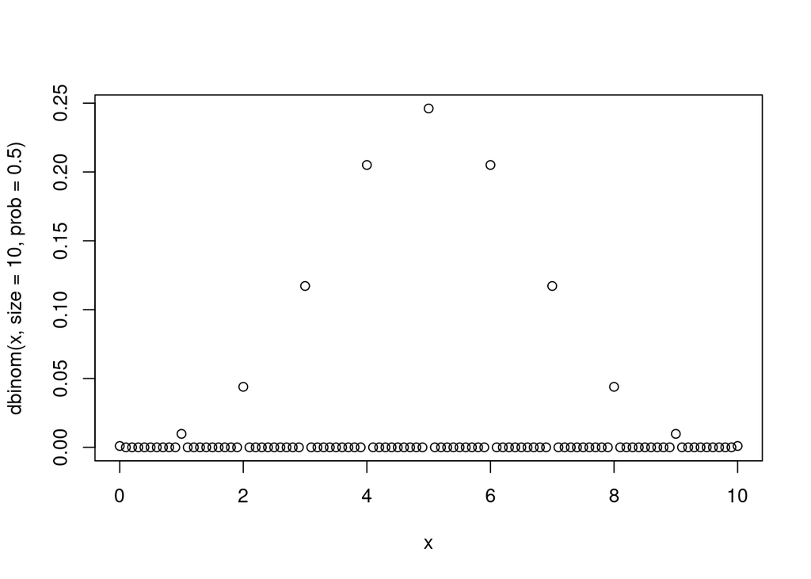

```r
curve(
    dbinom(x, size=10, prob=0.5),
    from = 0,
    to = 10,
    type = 'p', # It looks better using points rather than the default lines
)
```

You can use this function to calculate the probability that $X$ takes a certain value, say the value 4:

```r
dbinom(4, size=10, prob=0.5)
```

```
[1] 0.2050781
```

Or, if you’d like to know the probability that $X$ takes a value in a certain range, say 4-6 (inclusive):

```r
dbinom(4, size=10, prob=0.5) + dbinom(5, size=10, prob=0.5) + dbinom(6, size=10, prob=0.5)
```

```
[1] 0.65625
```

```r
# Actually, you can just do the following
sum(dbinom(4:6, size=10, prob=0.5))
```

```
[1] 0.65625
```

# The cumulative distribution function (pbinom)

The cumulative distribution function of $X$ is (like any discrete random variable) given by:

$$F(x) = P(X \leq x)= \sum_{k \leq
x}f(k)$$

In R this function is called `pbinom(x, size=10, prob=0.5)`. Here it is, plotted using curve:

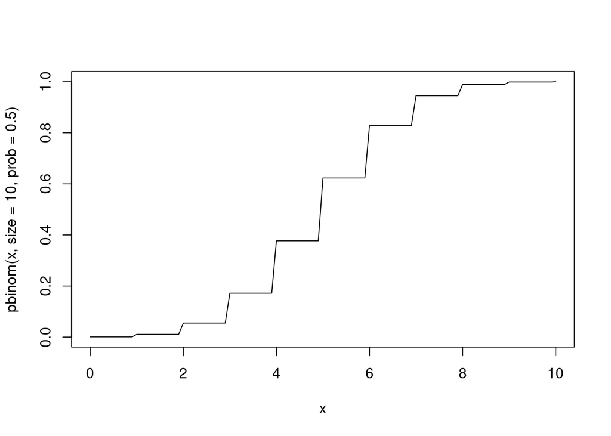

```r
curve(
  pbinom(x, size=10, prob=0.5),
  from = 0,
  to = 10,
)
```

You can use this function to calculate the probability that $X$ takes a value less than or equal to a certain value, say the number 4 (i.e. $P(x \leq 4)$ ):

```r
pbinom(4, size=10, prob=0.5)
```

```
[1] 0.3769531
```

You can calculate $P(x > 4)$ in a couple of different ways:

```r
1 - pbinom(4, size=10, prob=0.5)
```

```
[1] 0.6230469
```

```r
# Or
pbinom(4, size=10, prob=0.5, lower.tail=FALSE)
```

```
[1] 0.6230469
```

Note the addition of the `lower.tail=FALSE` argument in the second case. This tells the function to calculate $P(X > 4)$ rather than the default $P(X \leq 4)$.

You can also use this function to calculate the probability that $X$ takes a value in a certain range, say 4-6 (inclusive) (i.e. $P(4 \leq x \leq 6)$. You can do it in a couple of different ways:

```r
pbinom(6, size=10, prob=0.5) - pbinom(3, size=10, prob=0.5)
```

```
[1] 0.65625
```

```r
# Or
1 - pbinom(3, size=10, prob=0.5) - pbinom(6, size=10, prob=0.5, lower.tail=FALSE)
```

```
[1] 0.65625
```

# Quantiles `(qbinom)`

Suppose you’d like to know the value of $x$ such that $P(X \leq x) = 0.025$ - that is, the 2.5% quantile. That’s what the `qbinom` function is for:

```r
qbinom(0.025, size=10, prob=0.5)
```

```
[1] 2
```

Similarly, if you’d like to know the value of $x$ such that $P(X \leq x) = 0.975$ - that is, the 97.5% quantile, then you can find it as follows:

```r
qbinom(0.975, size=10, prob=0.5)
```

```
[1] 8
```

You can find both values at the same time, as follows:

```r
qbinom(c(0.025, 0.975), size=10, prob=0.5)
```

```
[1] 2 8
```

# Getting random values (`rbinom`)

If you’d like 100 randomly selected values of $X$ then you can get them using the `rbinom` function:

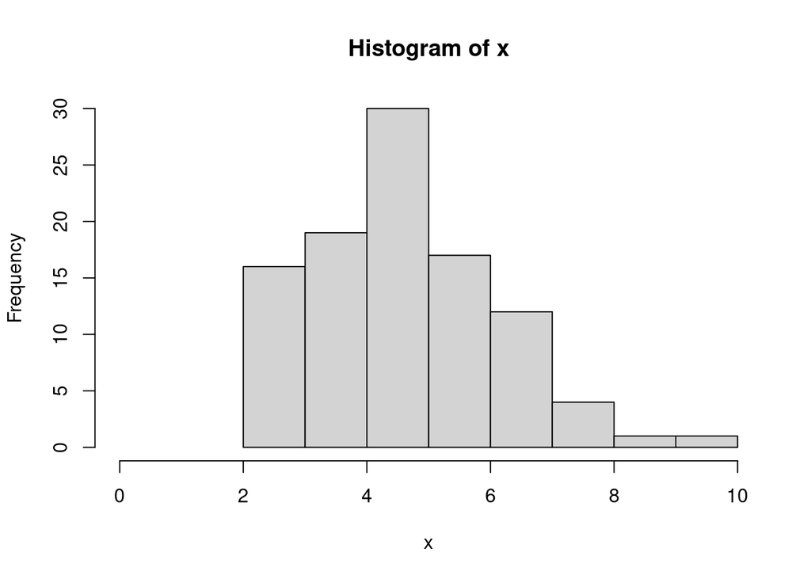

```r
x <- rbinom(n=100, size=10, prob=0.5)

# Plot a histogram of them
hist(x, xlim=c(0, 10))
```

# The geometric distribution

Consider the random process of rolling a fair six-sided die until you get a six. Let $X$ be the number of rolls before getting the six. Then $X$ is a discrete random variable with infinitely many possible values: 0, 1, 2, …. The probability distribution of $X$ is geometric, with parameter $p=1/6$. That is:

$$X \sim G(1/6)$$

The probability function (`dgeom`)

In R this is called `dgeom(x, prob=1/6)`. Here it is, plotted using curve:

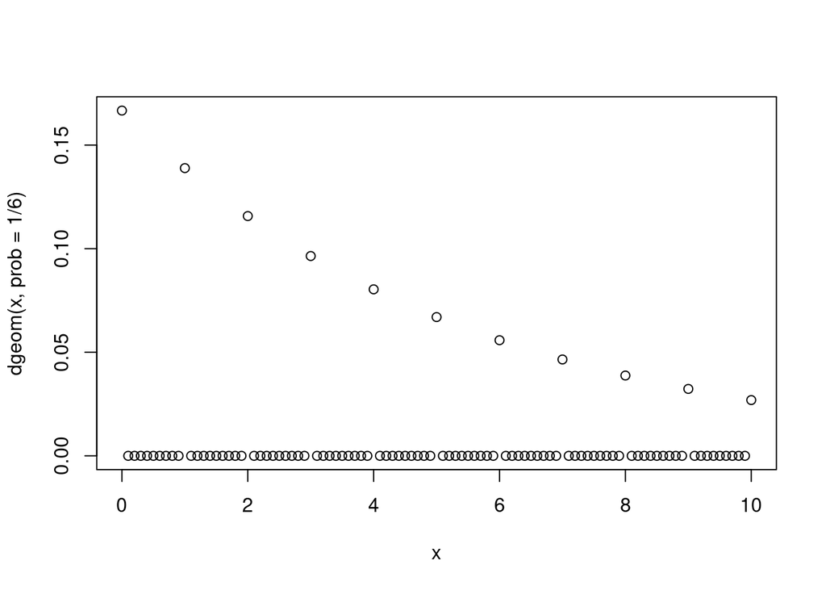

```r
curve(
  dgeom(x, prob=1/6),
  from = 0,
  to = 10,
  type = 'p',
)
```

You can use this function to calculate the probability that $X$ takes a certain value, say the value 4:

```r
dgeom(4, prob=1/6)
```

```
[1] 0.08037551
```

# The cumulative distribution function

The cumulative distribution function of $X$ is (like any discrete random variable) given by:

$$F(x) = P(X \leq x) = \sum_{k \leq x}
f(k)$$

In R this function is called `pgeom(x, prob=1/6)`. Here it is, plotted using curve:

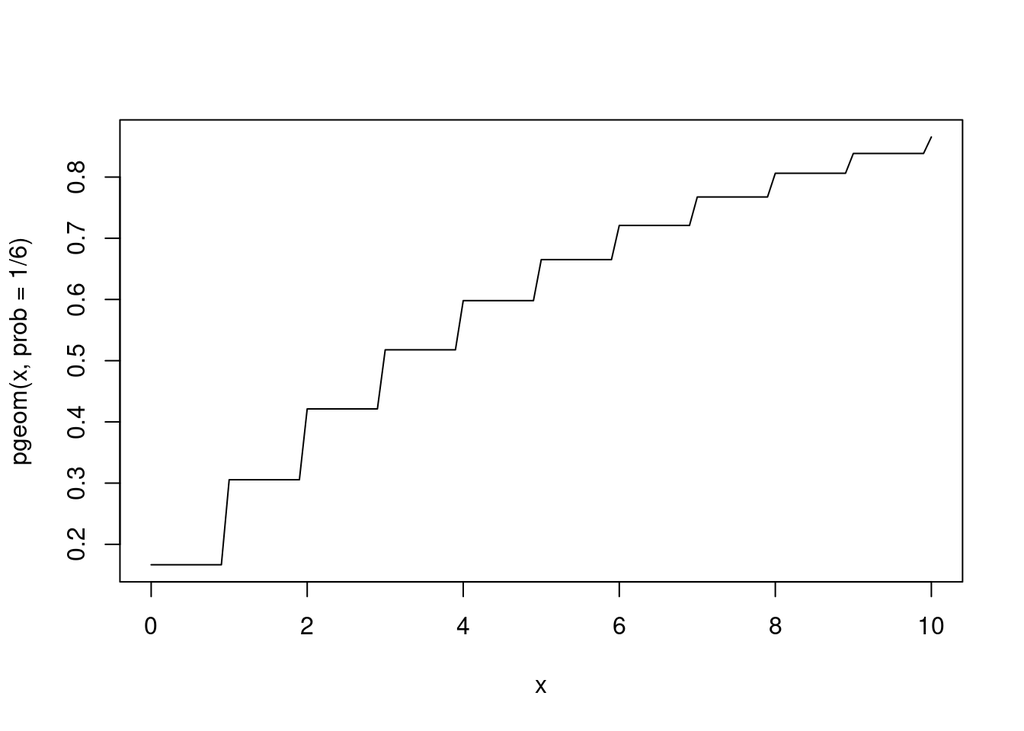

```r
curve(
  pgeom(x, prob=1/6),
  from = 0,
  to = 10,
)
```

You can use this function to calculate the probability that $X$ takes a value less than or equal to a certain value, say the number 4 (i.e. $P(x \leq 4)$):

```r
pgeom(4, prob=1/6)
```

```
[1] 0.5981224
```

# Quantiles (`qgeom`)

If you’d like to know the value of $x$ such that $P(X \leq x) = 0.5$ - that is, the 50% quantile - you can use `qgeom`:

```r
qgeom(0.5, prob=1/6)
```

```
[1] 3
```

# Getting random values (rgeom)

If you’d like 100 randomly selected values of $X$ then you can get them using the `rgeom` function:

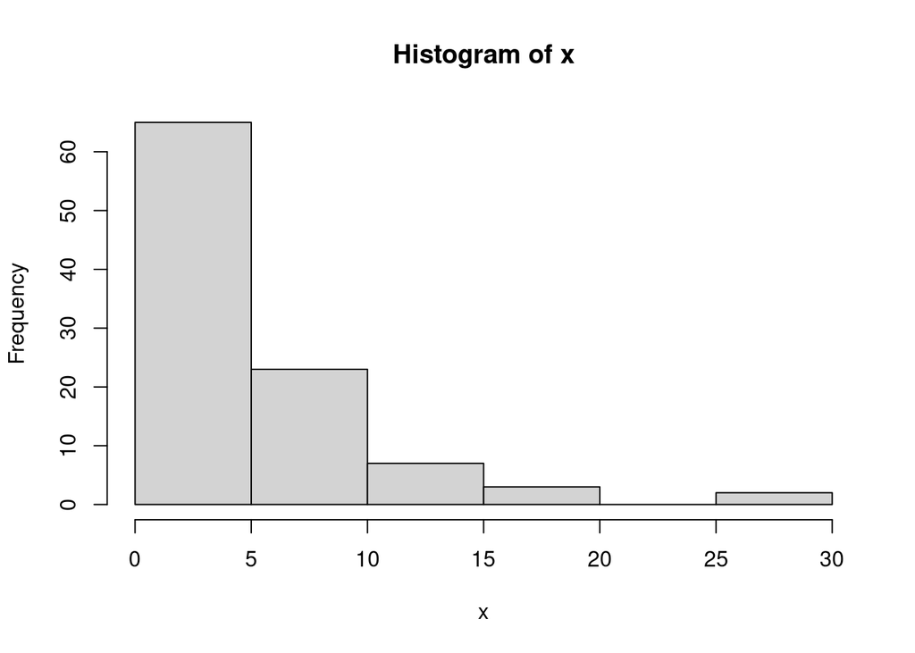

```r
x <- rgeom(n=100, prob=1/6)

# Plot a histogram of them
hist(x)
```

# The uniform distribution

Suppose that $X$ is a continuous random variable whose probability distribution is uniform, between 3 and 7. That is,

$$X \sim \text{Unif}(3,7)$$

## The density function (dunif)

In R this is called `dunif(x, min=3, max=7)`. Here it is, plotted using curve:

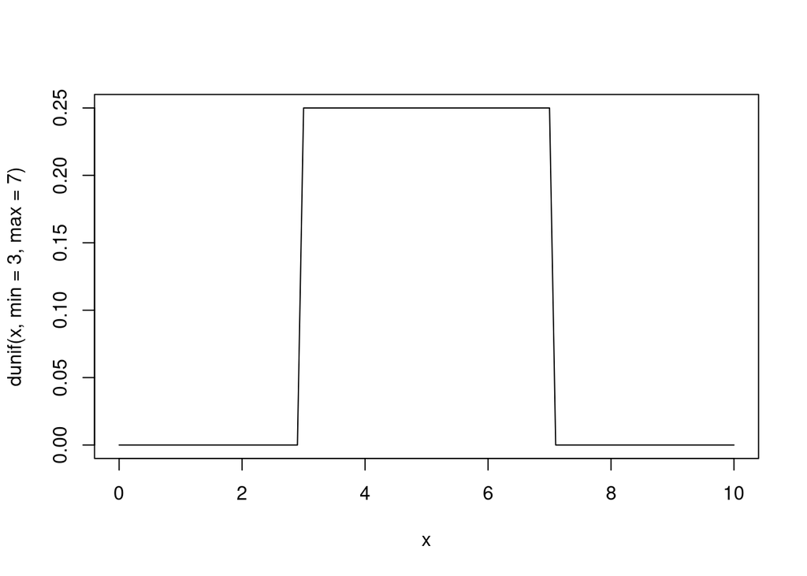

```r
curve(
  dunif(x, min=3, max=7),
  from = 0,
  to = 10,
)
```

# The cumulative distribution function (punif)

The cumulative distribution function of $X$ is (like any continuous random variable) given by:

$$F(x)=P(X \leq x) =
\int_{-\infty}^{x}f(t)dt$$

In R this function is called `punif(x, min=3, max=7)`. Here it is, plotted using curve:

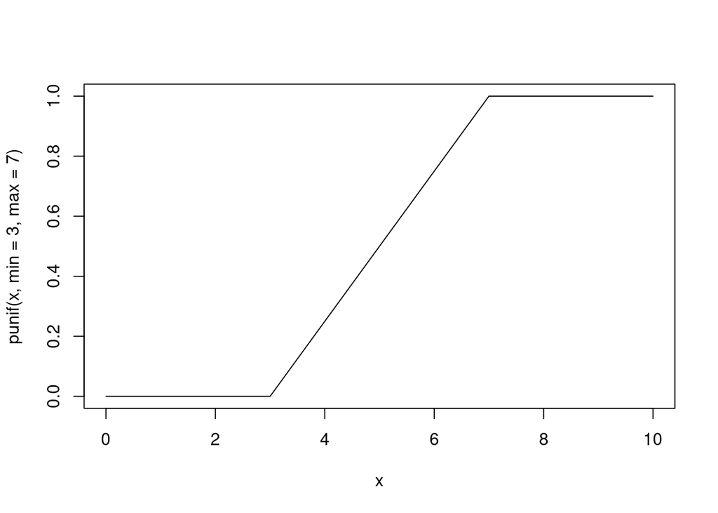

```r
curve(
  punif(x, min=3, max=7),
  from = 0,
  to = 10,
)
```

Here it is again, this time plotted together with the density function:

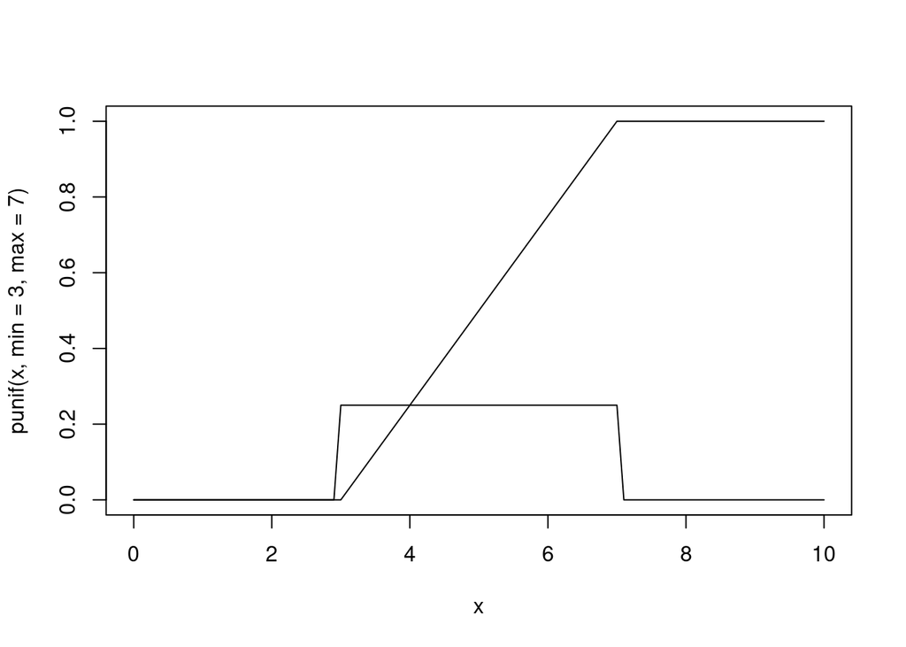

```r
curve(
  punif(x, min=3, max=7),
  from = 0,
  to = 10,
)
curve(
  dunif(x, min=3, max=7),
  from = 0,
  to = 10,
  add = TRUE # Add it to the same plot
)
```

You can use `punif` to calculate $P(x \leq 4)$:

```r
punif(4, min=3, max=7)
```

```
[1] 0.25
```

You can calculate $P(x>4)$ in a couple of different ways:

```r
1 - punif(4, min=3, max=7)
```

```
[1] 0.75
```

```r
# Or
punif(4, min=3, max=7, lower.tail=FALSE)
```

```
[1] 0.75
```

Similarly, you can calculate $P(4 < x \leq 5)$ in a couple of different ways:

```r
punif(5, min=3, max=7) - punif(4, min=3, max=7)
```

```
[1] 0.25
```

```r
# Or
1 - punif(4, min=3, max=7) - punif(5, min=3, max=7, lower.tail=FALSE)
```

```
[1] 0.25
```

# Quantiles (qunif)

If you’d like to know the value of x such that $P(X \leq x) = 0.5$ - that is, the 50% quantile - you can use `qunif`:

```r
qunif(0.5, min=3, max=7)
```

```
[1] 5
```

# Getting random values (runif)

If you’d like 100 randomly selected values of $X$ then you can get them using the `runif` function:

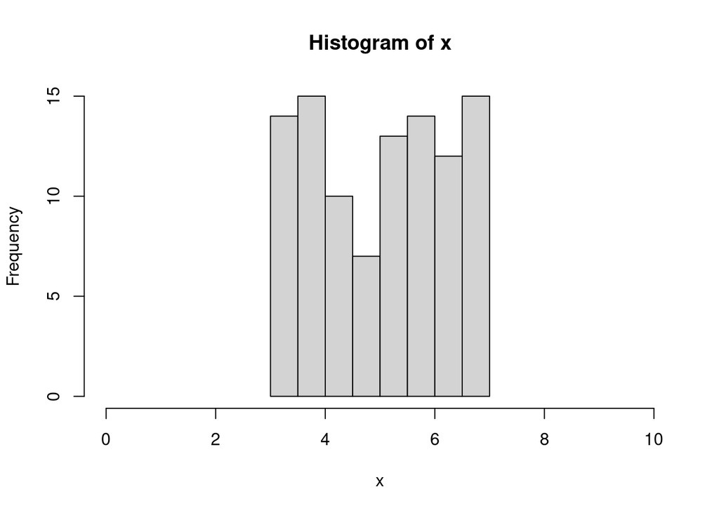

```r
x <- runif(n=100, min=3, max=7)

# Plot a histogram of them
hist(x, xlim=c(0, 10))
```

# The normal distribution

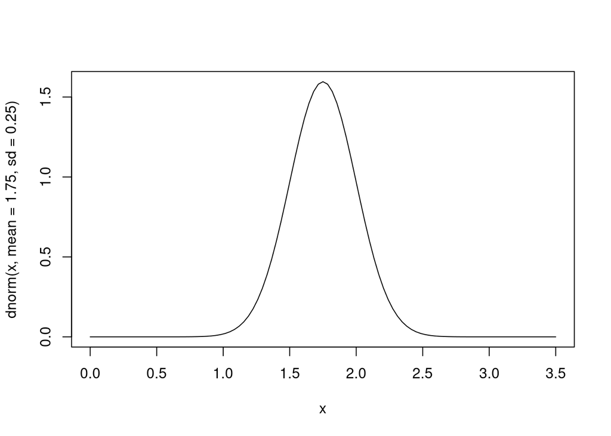

```r
curve(
  dnorm(x, mean=1.75, sd=0.25),
  from = 0,
  to = 3.5,
)
```

# The cumulative distribution function (pnorm)

In R this function is called `pnorm(x, mean=1.75, sd=0.25)`. Here it is, plotted using curve:

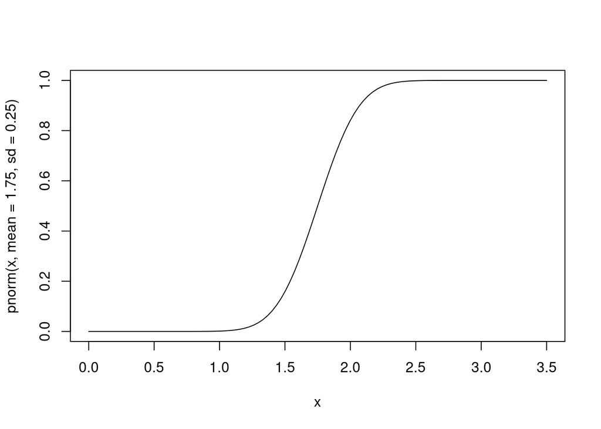

```r
curve(
  pnorm(x, mean=1.75, sd=0.25),
  from = 0,
  to = 3.5,
)
```

You can use `pnorm` to calculate the probability that $X$ falls within a given range:

```r
# P(X <= 1.5)
pnorm(1.5, mean=1.75, sd=0.25)
```

```
[1] 0.1586553
```

```r
# P(X > 1.8)
pnorm(1.8, mean=1.75, sd=0.25, lower.tail=FALSE)
```

```
[1] 0.4207403
```

```r
# P(1.5 < X <= 1.8)
pnorm(1.8, mean=1.75, sd=0.25) - pnorm(1.5, mean=1.75, sd=0.25)
```

```
[1] 0.4206045
```

# Quantiles (qnorm)

If you’d like to know the value of $X$ such that $P(X \leq x) =0.025$ - that is, the 2.5% quantile - you can use qnorm:

```r
qnorm(0.025, mean=1.75, sd=0.25)
```

```
[1] 1.260009
```

# Getting random values (`rnorm`)

If you’d like 100 randomly selected values of $X$ then you can get them using the `rnorm` function:

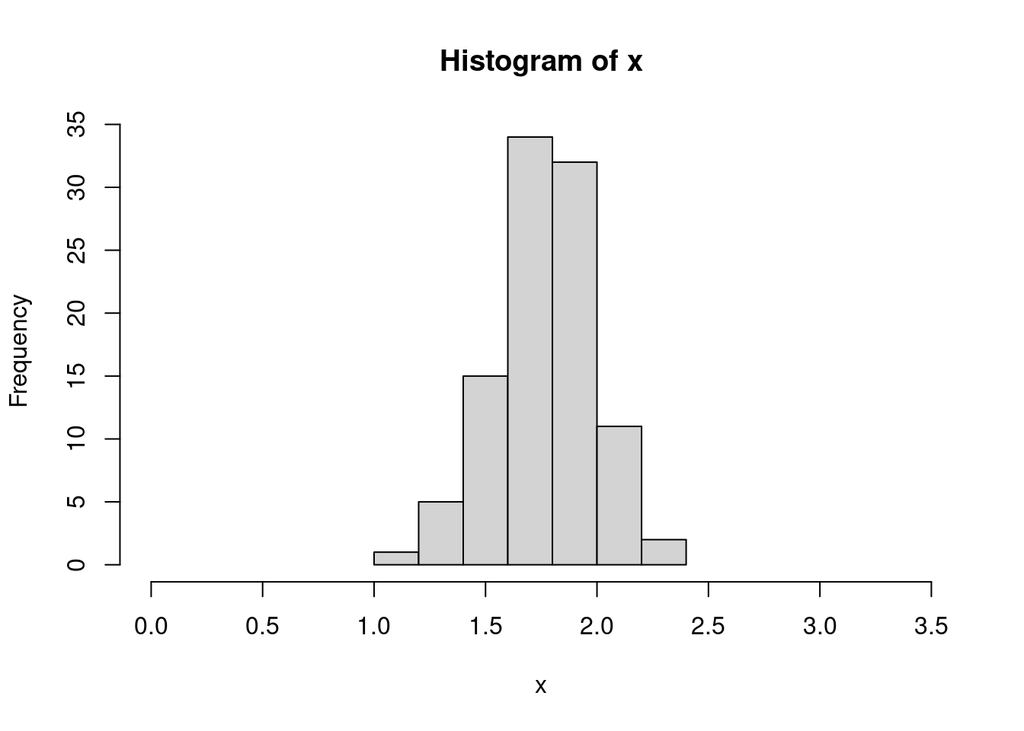

```r
x <- rnorm(n=100, mean=1.75, sd=0.25)

# Plot a histogram of them
hist(x, xlim=c(0, 3.5))
```

# Correlation and regression

You can use R to measure and visualise linear correlations, including calculating and displaying regression lines (i.e. lines of best fit).

Consider, for example, the iris dataset (built into R). Is there any correlation between sepal width and sepal length?

# Visual inspection

Let’s plot one against the other, to see if anything stands out:

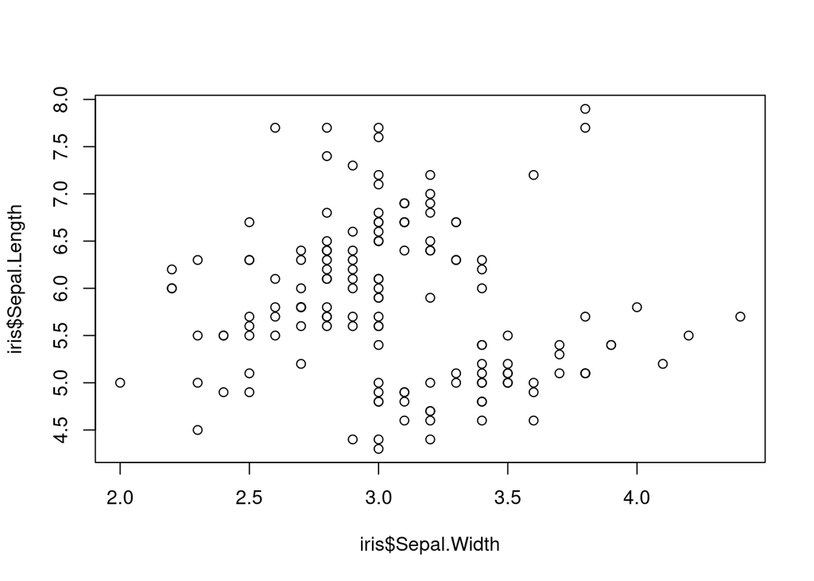

```r
plot(iris$Sepal.Width, iris$Sepal.Length)
```

Nothing obvious. What if we limit to just the species setosa?

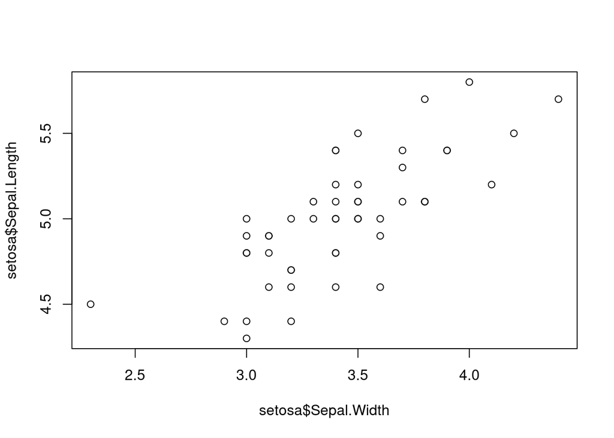

```r
setosa <- iris[iris$Species == 'setosa', ]
plot(setosa$Sepal.Width, setosa$Sepal.Length)
```

That looks more promising.

# Measuring correlation

You can use the function cor to measure the strength of the correlation:

```r
setosa <- iris[iris$Species == 'setosa', ]
cor(setosa$Sepal.Width, setosa$Sepal.Length)
```

```
[1] 0.7425467
```

By default, the Pearson method is used. You can change this to the Spearman method by adding the argument method=‘spearman’.

# Finding a regression line

You can use the lm function (short for “linear model”) to find the least squares line of best fit (regression line):

```r
setosa <- iris[iris$Species == 'setosa',]
model <- lm(setosa$Sepal.Length ~ setosa$Sepal.Width)
model
```

```
Call:
lm(formula = setosa$Sepal.Length ~ setosa$Sepal.Width)

Coefficients:
       (Intercept)  setosa$Sepal.Width
            2.6390              0.6905
```

Notice that the argument given to the lm function is a formula, which uses the tilde $\sim$. This formula specifies that we are interested in sepal length as a linear function of sepal width.

The lm function returns a linear model, which is an R object with a class attribute of “lm”. The output contains two numbers in a section titled Coefficients: one number is labelled (Intercept) - this is the y-intercept; the other number is the slope.

# Plotting the regression line

You can add the regression line to the scatter plot, using abline:

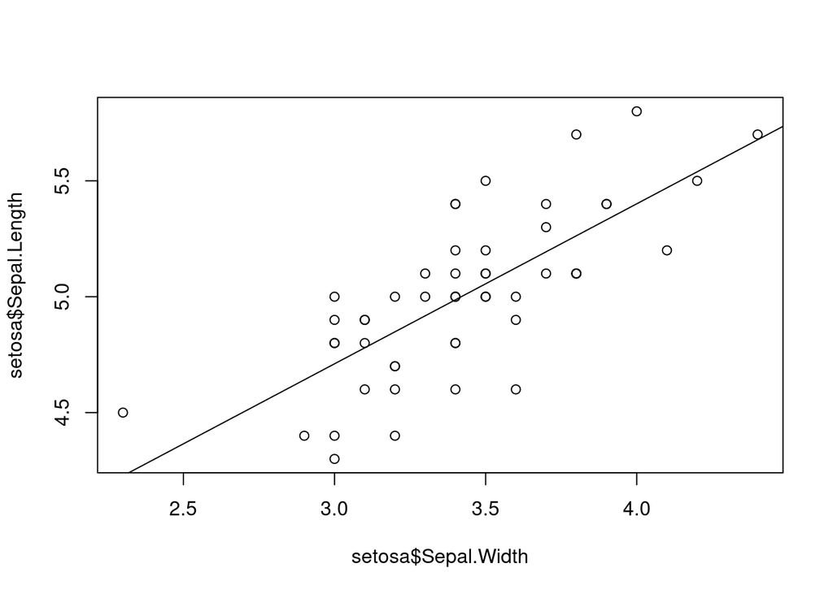

```r
setosa <- iris[iris$Species == 'setosa', ]
model <- lm(setosa$Sepal.Length ~ setosa$Sepal.Width)
plot(setosa$Sepal.Width, setosa$Sepal.Length)
abline(model)
```